# Python - Style Guides, Scripts, Imports - Practice Solutions

# QTM 350: Data Science Computing

# Davi Moreira

## Introduction

[figure not shown]

This topic material is based on the [Python Programming for Data Science](https://www.tomasbeuzen.com/python-programming-for-data-science/README.html) book and adapted for our purposes in the course.

## Exercise

Use `flake8` to list all the syntatic and stylistic problems with the following code. You could copy the code into a `.py` file and run `flake8` from the command line, or you could try the [JupyterLab flake8 extension](https://github.com/mlshapiro/jupyterlab-flake8).

```python
very_long_variable_name = {'field': 1,
                        'is_debug': True}
if very_long_variable_name is not None and very_long_variable_name["field"] > 0 or very_long_variable_name['is_debug']:
 z = 'hello '+'world'
else:
 f = rf'hello {world}'
if (True): y = 'hello ''world'#FIXME: https://github.com/python/black/issues/26
class Foo  (     object  ):
  def f    (self   ):
    return       37*-2
  def g(self, x,y=42):
      return y
regular_formatting = [
    0,  1,  2,
    3,  4,  5
]
def CAPITALIZE(mystring):
    return mystring.upper()
```

```python
!flake8 data/bad_style.py
```

[output not shown]

## Exercise

Use `black` to autoformat the following code. You could copy the code into a `.py` file and run `black` from the command line, or you could try the [JupyterLab black extension](https://jupyterlab-code-formatter.readthedocs.io/en/latest/index.html).

```python
very_long_variable_name = {'field': 1,
                        'is_debug': True}
if very_long_variable_name is not None and very_long_variable_name["field"] > 0 or very_long_variable_name['is_debug']:
 z = 'hello '+'world'
else:
 f = rf'hello {world}'
if (True): y = 'hello ''world'#FIXME: https://github.com/python/black/issues/26
class Foo  (     object  ):
  def f    (self   ):
    return       37*-2
  def g(self, x,y=42):
      return y
regular_formatting = [
    0,  1,  2,
    3,  4,  5
]
def CAPITALIZE(mystring):
    return mystring.upper()
```

```python
# I used the Jupyter Lab code formatter extension for this.

very_long_variable_name = {"field": 1, "is_debug": True}
if (
    very_long_variable_name is not None
    and very_long_variable_name["field"] > 0
    or very_long_variable_name["is_debug"]
):
    z = "hello " + "world"
else:
    f = rf"hello {world}"
if True:
    y = "hello " "world"  # FIXME: https://github.com/python/black/issues/26


class Foo(object):
    def f(self):
        return 37 * -2

    def g(self, x, y=42):
        return y


regular_formatting = [0, 1, 2, 3, 4, 5]


def CAPITALIZE(mystring):
    return mystring.upper()
```

## Exercise

In the last set of practice exercises we created the `Circle` class:

```
class Circle:
    """A circle with a radius r."""

    def __init__(self, radius):
        self.radius = radius

    def area(self):
        """Calculate the area of the circle."""
        return math.pi * self.radius ** 2

    def circumference(self):
        """Calculate the circumference of the circle."""
        return 2.0 * math.pi * self.radius

    def __str__(self):
        return f"A Circle with radius {self.radius}"
```

Save this code into a new Python `.py` file and then import it here and answer the following:

1. What is the area of a circle with radius 10?
2. What is the circumference of a circle with radius 10?

```python
code = """
import math

class Circle:
    \"\"\"A circle with a radius r.\"\"\"

    def __init__(self, radius):
        self.radius = radius

    def area(self):
        \"\"\"Calculate the area of the circle.\"\"\"
        return math.pi * self.radius ** 2

    def circumference(self):
        \"\"\"Calculate the circumference of the circle.\"\"\"
        return 2.0 * math.pi * self.radius

    def __str__(self):
        return f\"A Circle with radius {self.radius}\"
"""

file_path = 'data/circle.py'

with open(file_path, 'w') as file:
    file.write(code)

print(f"The code has been saved to {file_path}")
```

```
The code has been saved to data/circle.py
```

```python
import sys
sys.path.append('data/')
from circle import Circle

c = Circle(10)
print(f"The circle has area = {c.area():.2f}")
print(f"The circle has circumference = {c.circumference():.2f}")
```

```
The circle has area = 314.16
The circle has circumference = 62.83
```

## Exercise

I recently decided to simulate the possible attendance at a party I was throwing using Python. The idea is that for every guest you invite, you assign them a probability of actually attending your party. For example:

| Guest Name | Probability of Attending |
| --- | --- |
| Davi | 1 |
| Juliana | 0.75 |
| Tiffany | 0.5 |
| Joel | 0.75 |
| Alexi | 0.5 |
| Joel | 1 |
| Mike | 0.5 |
| Gabriel | 0.75 |

In this exercise I want you to create a function that models each guest's attendance as a [Bernoulli random variable](https://en.wikipedia.org/wiki/Bernoulli_distribution). You can run a Bernoulli trial using the `numpy` library function `random.binomial(n=1, ...)` (here are the [docs](https://numpy.org/doc/stable/reference/random/generated/numpy.random.binomial.html)). You should import this function and run a single simulation on the list above (note that results may vary as we won't fix the random seed here).

I've given you the list of probabilities to get you started. Your code should output the total number of attendees after running your simulation.

*This question is based on a [random website post by Tomas Beuzen](https://www.tomasbeuzen.com/post/party-planning-probability/).*

```python
probabilities = [1, 0.75, 0.5, 0.75, 0.5, 1, 0.5, 0.75]

import numpy as np

attendance_simulation = [np.random.binomial(n=1, p=p) for p in probabilities]
print(f"{sum(attendance_simulation)} guests attended the party in this simulation!")
```

```
6 guests attended the party in this simulation!
```

## Exercise

So after completing Exercise 4, you have a way of running a single simulation given a list of probabilities. Now I want you to write a function called `simulate_party(probabilities, n)` that runs `n` simulations for a list of `probabilities` and returns a list of the total number of attendees for each simulation.

Then, calculate the average guest attendance after running 100 simulations (round up to the nearest integer - hint: `math.ceil()`).

```python
import math


def simulate_party(probabilities, n):
    "Simulate attendance at a party from a list of attendance probabilities."

    attendance = []
    for i in range(n):
        attendance.append(sum([np.random.binomial(n=1, p=p) for p in probabilities]))
    return attendance


simulations = simulate_party(probabilities, 100)

print(
    f"Avg. number of guests across all simulations: {math.ceil(sum(simulations) / len(simulations))}"
)
```

```
Avg. number of guests across all simulations: 6
```

Once you have a working function, uncomment the code below to plot the results of your function on a much longer guest list!

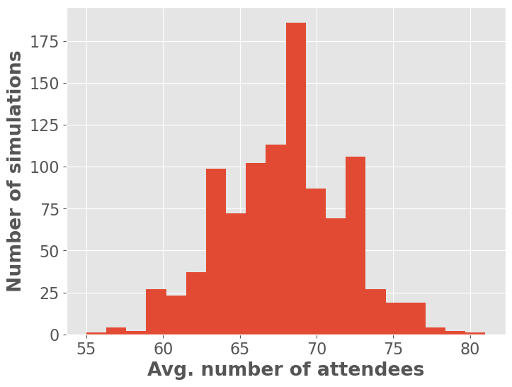

```python
# Use this code to plot your function on a bigger guest list!
import numpy as np
import matplotlib.pyplot as plt
plt.style.use('ggplot')  # These lines are to do with plot formatting. We'll talk about them later.
plt.rcParams.update({'font.size': 16, 'axes.labelweight': 'bold', 'figure.figsize': (8, 6)})

number_of_guests=100
probabilities = np.random.choice([0.2, 0.4, 0.6, 0.8, 1],
                                 size=number_of_guests,
                                 p=[0.1, 0.2, 0.2, 0.3, 0.2])

attendance = simulate_party(probabilities, n=1000)
plt.hist(attendance, bins=20)
plt.xlabel("Avg. number of attendees")
plt.ylabel("Number of simulations");
```

```python
!jupyter nbconvert _04-py-style-scripts-imports-practice-solutions.ipynb --to html --template classic --output 04-py-style-scripts-imports-practice-solutions.html
```

[output not shown]